# lab08

Dylan Scoble

3/10/2022

```r
gss <- read_csv("data/gss2016.csv",
  na = c("", "Don't know", "No answer",
         "Not applicable"),
         guess_max = 2867) %>%
  select(natmass, age, sex, sei10, region, polviews) %>%
  drop_na()
```

# Part I: Exploratory Data Analysis

### Exercise 1

```r
gss <- gss %>%
  mutate(natmass = fct_relevel(natmass, "About right", "Too little", "Too much"))
```

### Exercise 2

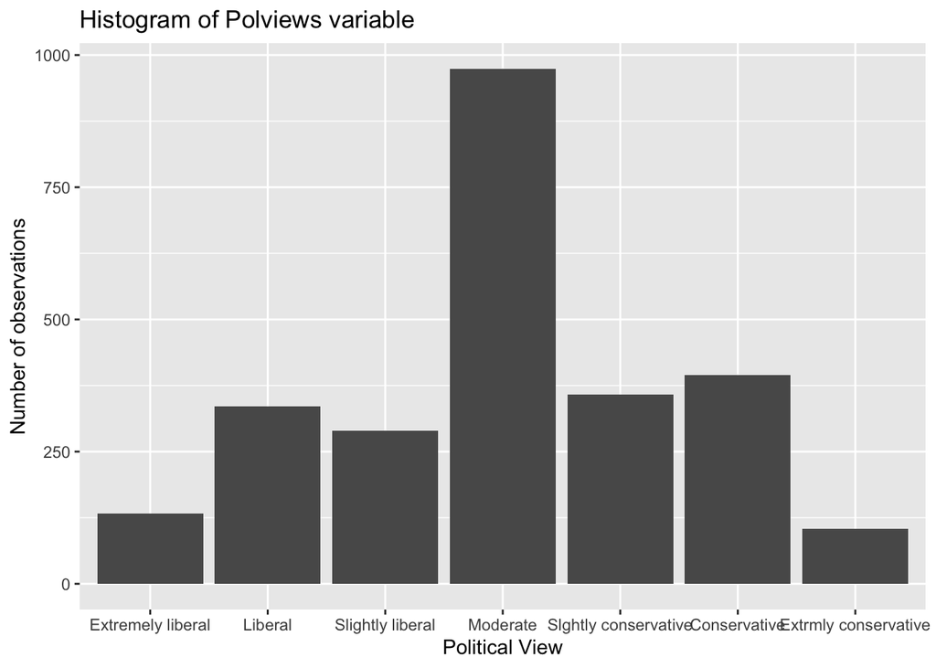

```r
gss <- gss %>%
  mutate(polviews = fct_relevel(polviews, "Extremely liberal", "Liberal", "Slightly liberal", "Moderate", "Slghtly conservative", "Conservative", "Extrmly conservative"))

ggplot(data = gss, aes(x = polviews)) +
  geom_bar() +
  labs(title = "Histogram of Polviews variable",
       x="Political View",
       y="Number of observations")
```

The most popular political view in this dataset is “Moderate” by a large margin.

### Exercise 3

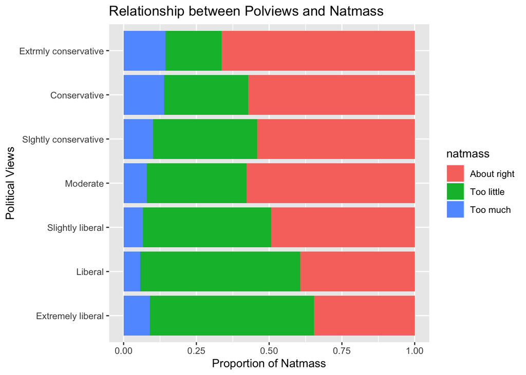

```r
ggplot(data = gss, aes(fill=natmass, x=polviews)) +
  geom_bar(position="fill") +
  labs(title = "Relationship between Polviews and Natmass",
       x="Political Views",
       y="Proportion of Natmass") +
  coord_flip()
```

This plot tells us that liberals tend to believe that the government spending on mass transportation is not enough. The more conservative an individual is, the more likely it is that they believe government spending on mass transportation is enough or too much.

### Exercise 4

```r
gss <- gss %>%
  mutate(age = if_else(age == "89 or older", 89, as.numeric(age)))
```

# Part II: Multinomial Logistic Regression Model

### Exercise 5

A multinomial logistic regression model is the best choice for this problem because our response variable, Natmass, is a categorical variable with more than two categories. Logistic regression handles classification problems and because there are three categories for our classifier, we can not use a binomial model.

### Exercise 6

```r
model <- multinom(natmass ~ ., data = gss)
tidy(model) %>%
  kable(format = "markdown", digits = 4)
```

| y.level | term | estimate | std.error | statistic | p.value |
| --- | --- | --- | --- | --- | --- |
| Too little | (Intercept) | -0.4149 | 0.2584 | -1.6058 | 0.1083 |
| Too little | age | 0.0062 | 0.0025 | 2.4478 | 0.0144 |
| Too little | sexMale | 0.2174 | 0.0870 | 2.4996 | 0.0124 |
| Too little | sei10 | 0.0081 | 0.0018 | 4.4463 | 0.0000 |
| Too little | regionE. sou. central | 0.3339 | 0.1923 | 1.7359 | 0.0826 |
| Too little | regionMiddle atlantic | -0.0815 | 0.1674 | -0.4865 | 0.6266 |
| Too little | regionMountain | 0.1377 | 0.1798 | 0.7658 | 0.4438 |
| Too little | regionNew england | 0.4660 | 0.2053 | 2.2701 | 0.0232 |
| Too little | regionPacific | 0.3637 | 0.1539 | 2.3636 | 0.0181 |
| Too little | regionSouth atlantic | 0.1319 | 0.1418 | 0.9296 | 0.3526 |
| Too little | regionW. nor. central | 0.0306 | 0.1993 | 0.1535 | 0.8780 |
| Too little | regionW. sou. central | -0.0275 | 0.1715 | -0.1606 | 0.8724 |
| Too little | polviewsLiberal | -0.2016 | 0.2226 | -0.9057 | 0.3651 |
| Too little | polviewsSlightly liberal | -0.5969 | 0.2267 | -2.6330 | 0.0085 |
| Too little | polviewsModerate | -0.9695 | 0.2026 | -4.7847 | 0.0000 |
| Too little | polviewsSlghtly conservative | -0.9400 | 0.2224 | -4.2264 | 0.0000 |
| Too little | polviewsConservative | -1.2207 | 0.2237 | -5.4558 | 0.0000 |
| Too little | polviewsExtrmly conservative | -1.6962 | 0.3199 | -5.3021 | 0.0000 |
| Too much | (Intercept) | -1.8496 | 0.4356 | -4.2463 | 0.0000 |
| Too much | age | 0.0143 | 0.0041 | 3.4804 | 0.0005 |
| Too much | sexMale | 0.5349 | 0.1462 | 3.6596 | 0.0003 |
| Too much | sei10 | -0.0099 | 0.0032 | -3.0785 | 0.0021 |
| Too much | regionE. sou. central | -0.3234 | 0.3508 | -0.9217 | 0.3567 |
| Too much | regionMiddle atlantic | -0.1435 | 0.2791 | -0.5143 | 0.6070 |
| Too much | regionMountain | -0.0255 | 0.3048 | -0.0835 | 0.9334 |
| Too much | regionNew england | 0.8785 | 0.2922 | 3.0065 | 0.0026 |
| Too much | regionPacific | 0.3403 | 0.2438 | 1.3956 | 0.1628 |
| Too much | regionSouth atlantic | -0.2740 | 0.2428 | -1.1283 | 0.2592 |
| Too much | regionW. nor. central | 0.1593 | 0.3038 | 0.5243 | 0.6001 |
| Too much | regionW. sou. central | -0.6018 | 0.3114 | -1.9328 | 0.0533 |
| Too much | polviewsLiberal | -0.6307 | 0.4113 | -1.5333 | 0.1252 |
| Too much | polviewsSlightly liberal | -0.6699 | 0.4110 | -1.6298 | 0.1031 |
| Too much | polviewsModerate | -0.6797 | 0.3510 | -1.9362 | 0.0528 |
| Too much | polviewsSlghtly conservative | -0.4011 | 0.3768 | -1.0645 | 0.2871 |
| Too much | polviewsConservative | -0.0798 | 0.3640 | -0.2193 | 0.8264 |
| Too much | polviewsExtrmly conservative | -0.3064 | 0.4429 | -0.6918 | 0.4891 |

### Exercise 7

Because the coeficients of the of intercepts for “Too Little” and “Too Much” are both negative, this tells us that the model will favor the more neutral baseline in its predictions.

### Exercise 8

The coefficient of age of “Too little” against the baseline is slightly positive. This tells us that as an individual gets older, the odds of them thinking that mass transportation spending is too little increases.

### Exercise 9

The null hypothesis states that attitude towards spending on mass transportation is not affected by political views. The alternative hypothesis states that attitude towards spending on mass transportation is affected by political views. In a statistical sense, I will compare the model above to a model that does not include the polviews variable. If the reduced model has a lower AIC, then the null hypothesis holds true.

```r
reduced_model <- multinom(natmass ~ age + sex + sei10 + region, data = gss)
reduced_model$AIC
```

```
## [1] 4702.447
```

```r
model$AIC
```

```
## [1] 4623.845
```

In conclusion, the model that includes the polviews variable has a lower AIC. Thus, the alternative hypothesis is correct. We will use the full model for the remainder of the lab.

# Part III: Model Fit

### Exercise 11

```r
fitted <- model$fitted.values
resid <- model$residuals

head(fitted)
```

```
##   About right Too little   Too much
## 1   0.3824439  0.5151564 0.10239965
## 2   0.2715367  0.5756776 0.15278570
## 3   0.5246593  0.3253687 0.14997198
## 4   0.4155186  0.4653015 0.11917992
## 5   0.4138702  0.4762595 0.10987027
## 6   0.3142385  0.5904887 0.09527281
```

```r
head(resid)
```

```
##   About right Too little    Too much
## 1  -0.3824439  0.4848436 -0.10239965
## 2  -0.2715367  0.4243224 -0.15278570
## 3  -0.5246593 -0.3253687  0.85002802
## 4  -0.4155186  0.5346985 -0.11917992
## 5   0.5861298 -0.4762595 -0.10987027
## 6  -0.3142385  0.4095113 -0.09527281
```